# AMED3002 Lab 1 Report

## Results

To generate the following plots, the libraries:`ggplot2` and `dplyr`, were used for data visualization and manipulation.

```r
# Libraries used
library(ggplot2)
library(dplyr)
```

### Age vs. Systolic Blood Pressure by Prevalent Angina Pectoris

The raw data was filtered to include only living individuals, ensuring the analysis focused on the relationship between systolic blood pressure (`SYSBP`) and age. Additionally, rows with missing values in the `ANGINA` column were removed to ensure data integrity.

The median age and systolic blood pressure was also calculated for each angina group.

```r
filtered_data <- frmgham_data[frmgham_data$DEATH == "Alive", ]

filtered_data <- filtered_data[!is.na(filtered_data$ANGINA), ]

centers <- filtered_data %>%
  group_by(ANGINA) %>%
  summarise(center_AGE = median(AGE, na.rm = TRUE),
            center_SYSBP = median(SYSBP, na.rm = TRUE))
```

Figure 1 below illustrates the distribution of systolic blood pressure across different ages, separated by the prevalence of Angina Pectoris. The density heatmap highlights regions with a higher concentration of individuals, with warmer colors representing higher densities. Additionally, the median age and systolic blood pressure for each group are marked to provide a central tendency reference.

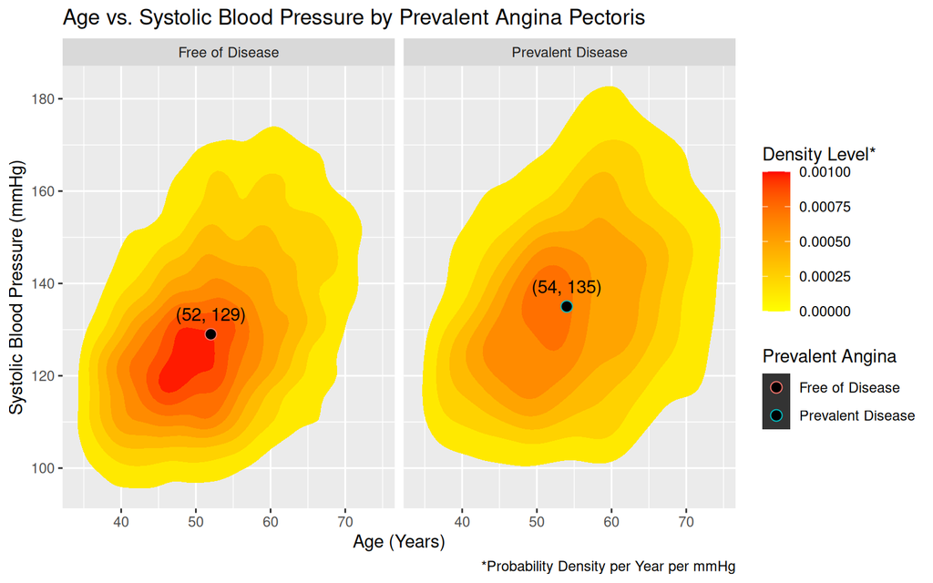

Figure 1: A topographical plot displaying the ranges of systolic blood pressure against age separated by the prevalence of Angina Pectoris with points showing the median age and systolic blood pressure

```r
ggplot(filtered_data, aes(x = AGE, y = SYSBP)) +
  labs(title = "Age vs. Systolic Blood Pressure by Prevalent Angina Pectoris",
       x = "Age (Years)",
       y = "Systolic Blood Pressure (mmHg)",
       color = "Prevalent Angina",
       caption = "*Probability Density per Year per mmHg") +
  stat_density2d(
    aes(x=AGE, y=SYSBP, fill = ..level..),
    size=0,
    bins=9,
    data=as.data.frame(filtered_data),
    geom="polygon") +
  facet_grid(col = vars(ANGINA)) +
  scale_fill_gradient(low = "yellow", high = "red", name = "Density Level*",
                      limits = c(0, 0.001)) +
  geom_point(data = centers,
             aes(x = center_AGE,
                 y = center_SYSBP,
                 color = ANGINA),
             size = 3, shape = 21,
             fill = "black") +
  geom_text(data = centers,
            aes(x = center_AGE,
                y = center_SYSBP,
                label = paste0("(", center_AGE, ", ", center_SYSBP, ")")),
            vjust = -1)
```

From the Figure 1, we observe that individuals without disease tend to have lower systolic blood pressure on average compared to those with prevalent angina. This suggests a potential association between higher blood pressure and the presence of angina. Furthermore, the disease-free group exhibits a more concentrated distribution at lower values, implying that their blood pressure levels are relatively stable and fall within a narrower range. In contrast, individuals with prevalent angina show a more dispersed distribution, suggesting greater variability in blood pressure, which may be influenced by other factors.